# NDFS Contaminants Manuscript

# Water Analysis

```r
# Prepare water concentration data for analysis
df_water <- df_conc_all_c2 %>%
  select(-TotalConc_Zoop) %>%
  # only include 2019 since that was the only year water samples were collected
    # at STTD
  filter(Year == 2019) %>%
  drop_na() %>%
  # Add log-transformed and sqrt-transformed zooplankton concentrations
  mutate(
    TotalConc_Water_log = log(TotalConc_Water),
    TotalConc_Water_sqrt = sqrt(TotalConc_Water)
  )
```

## Exploratory Plots

Before running the analyses, lets visualize the data.

### Boxplots

First, let’s look at a boxplot comparing total pesticide concentrations in water between stations.

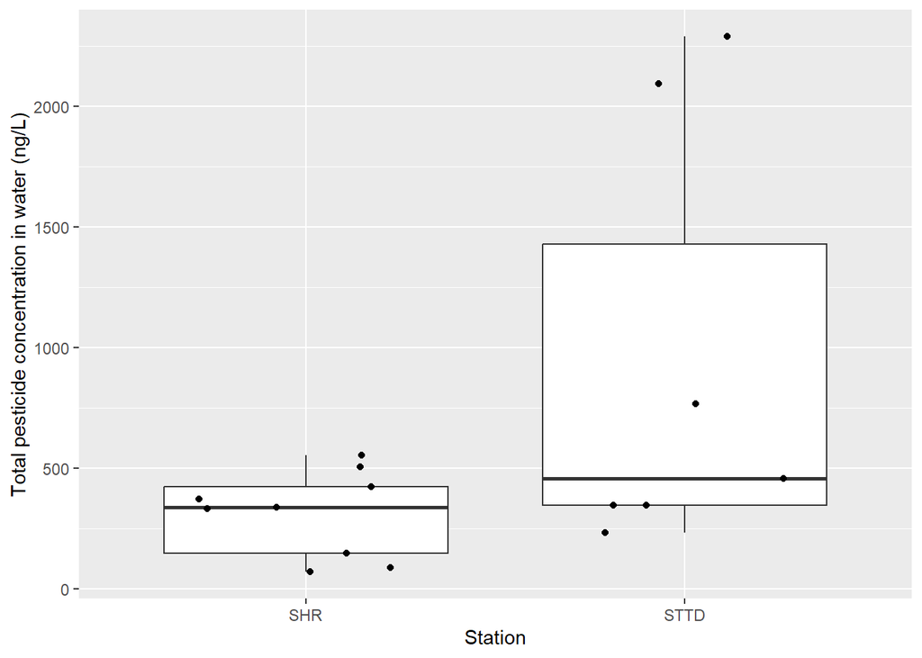

```r
df_water %>%
  ggplot(aes(x = Station, y = TotalConc_Water)) +
  geom_boxplot(outlier.shape = NA) +
  geom_jitter(width = 0.3) +
  ylab("Total pesticide concentration in water (ng/L)")
```

STTD seems to have higher concentrations with much more variation than SHR.

### Seasonal time-series

Now, let’s see how total concentrations varied seasonally in 2019 for each station.

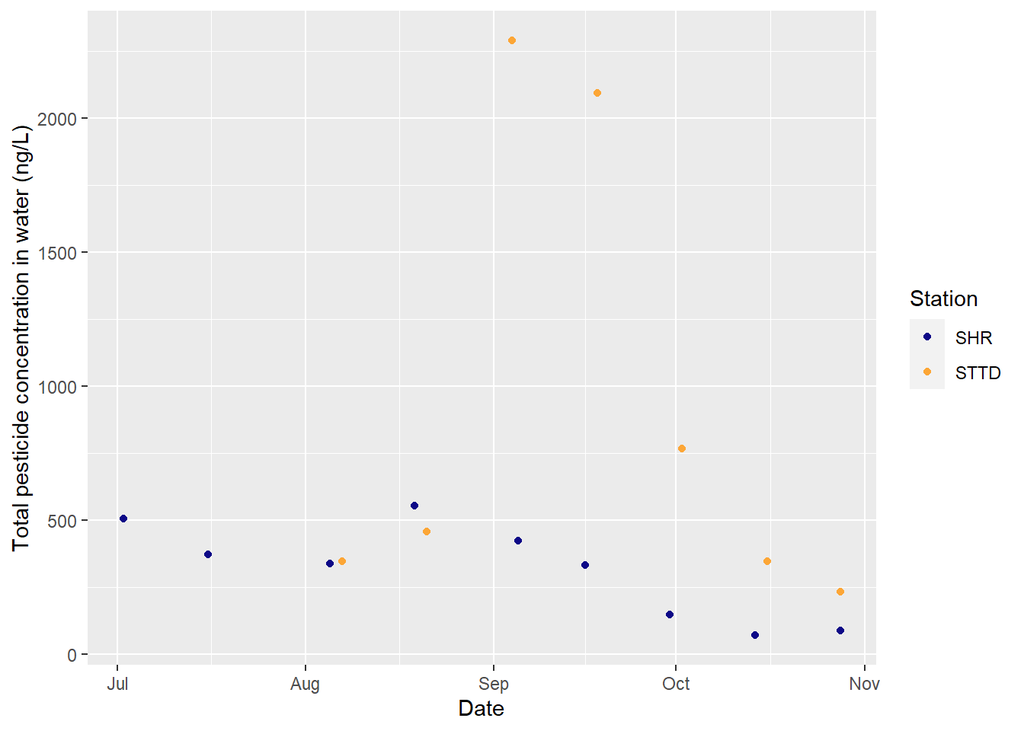

```r
df_water %>%
  ggplot(aes(x = Date, y = TotalConc_Water, color = Station)) +
  geom_point() +
  scale_color_viridis_d(option = "plasma", end = 0.8) +
  labs(x = "Date", y = "Total pesticide concentration in water (ng/L)")
```

### Concentration vs Flow

Now, let’s take a look at how the total pesticide concentrations in water vary with daily average net flow for each station.

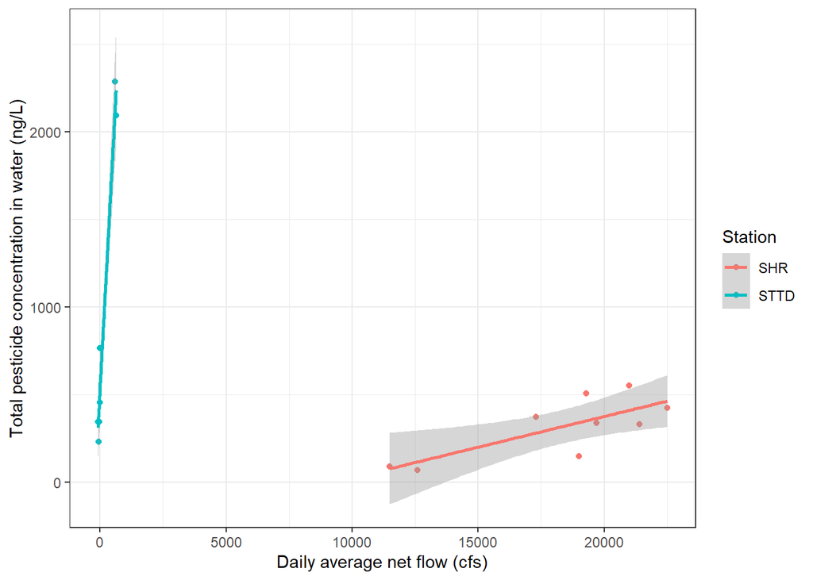

```r
df_water %>%
  ggplot(aes(x = DailyAvgNetFlow, y = TotalConc_Water, color = Station)) +
  geom_point() +
  geom_smooth(method = "lm", formula = y ~ x) +
  labs(
    x = "Daily average net flow (cfs)",
    y = "Total pesticide concentration in water (ng/L)"
  ) +
  theme_bw()
```

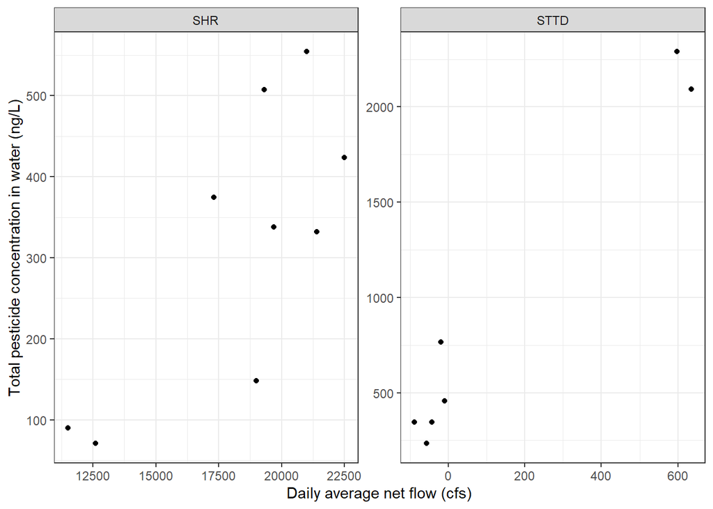

```r
df_water %>%
  ggplot(aes(x = DailyAvgNetFlow, y = TotalConc_Water)) +
  geom_point() +
  facet_wrap(vars(Station), scales = "free") +
  labs(
    x = "Daily average net flow (cfs)",
    y = "Total pesticide concentration in water (ng/L)"
  ) +
  theme_bw()
```

### Concentration vs Application

Next, let’s look at the total pesticide concentrations in water as a function of standardized monthly total application data for each station.

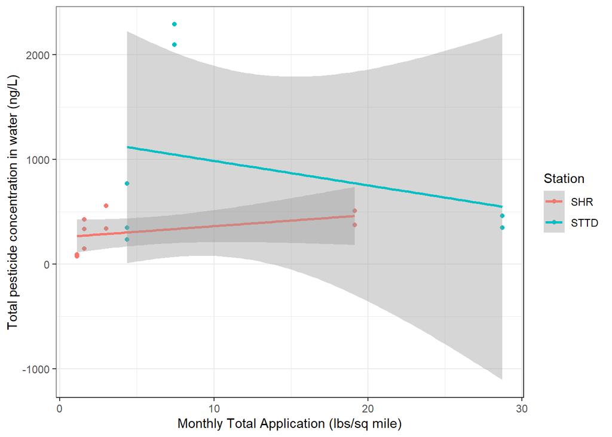

```r
df_water %>%
  ggplot(aes(x = TotalApplStd, y = TotalConc_Water, color = Station)) +
  geom_point() +
  geom_smooth(method = "lm", formula = y ~ x) +
  labs(
    x = "Monthly Total Application (lbs/sq mile)",
    y = "Total pesticide concentration in water (ng/L)"
  ) +
  theme_bw()
```

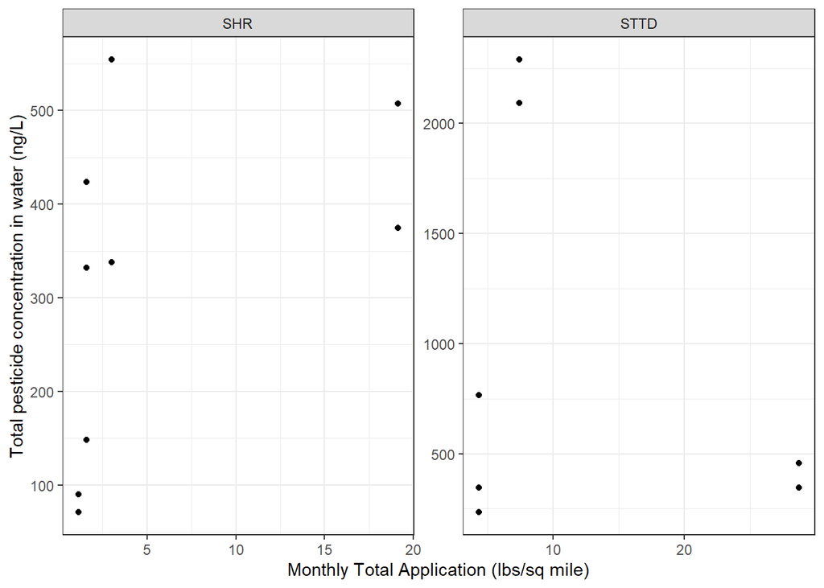

```r
df_water %>%
  ggplot(aes(x = TotalApplStd, y = TotalConc_Water)) +
  geom_point() +
  scale_color_viridis_d(option = "plasma", end = 0.8) +
  facet_wrap(vars(Station), scales = "free") +
  labs(
    x = "Monthly Total Application (lbs/sq mile)",
    y = "Total pesticide concentration in water (ng/L)"
  ) +
  theme_bw()
```

There appears to be a weak negative relationship between pesticide concentrations in water and monthly application amounts at STTD and a slightly stronger positive relationship at SHR. I’m not sure that monthly application will be a good predictor. Let’s take a look at whether using the prior month’s application amount makes a difference.

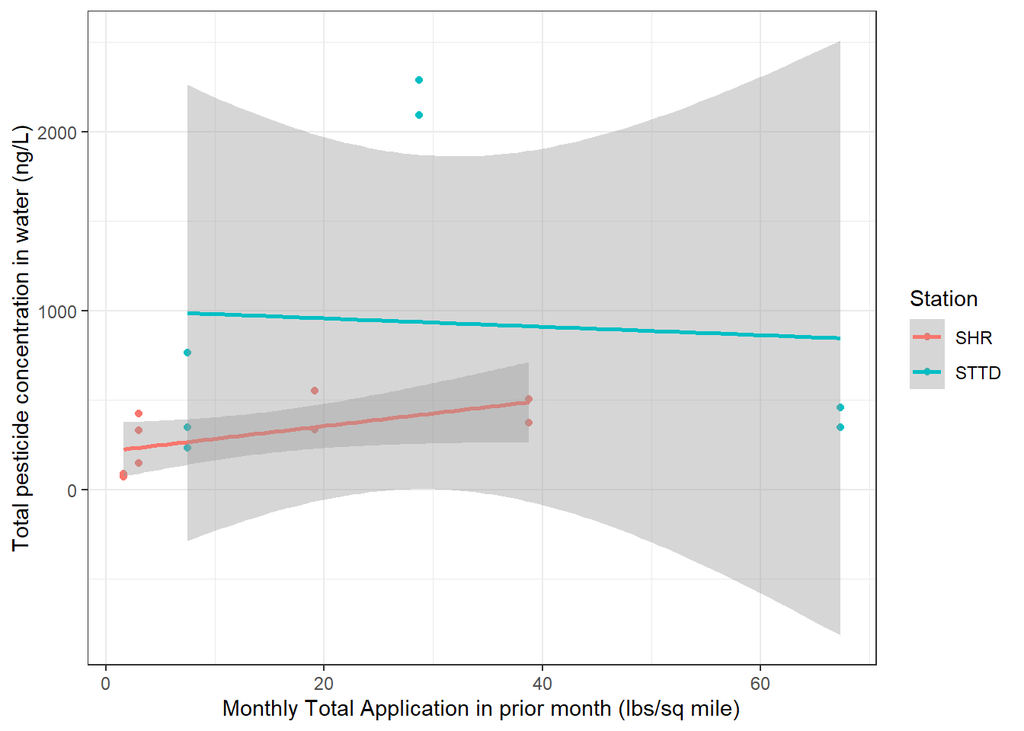

```r
df_water %>%
  ggplot(aes(x = TotalApplStd_lag1, y = TotalConc_Water, color = Station)) +
  geom_point() +
  geom_smooth(method = "lm", formula = y ~ x) +
  labs(
    x = "Monthly Total Application in prior month (lbs/sq mile)",
    y = "Total pesticide concentration in water (ng/L)"
  ) +
  theme_bw()
```

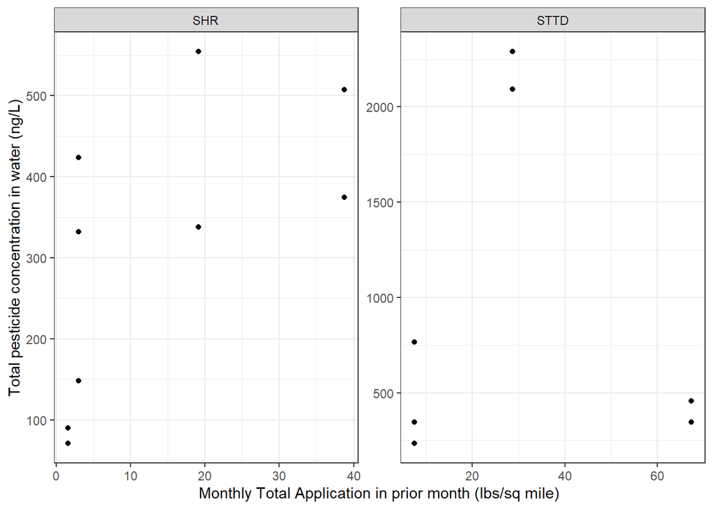

```r
df_water %>%
  ggplot(aes(x = TotalApplStd_lag1, y = TotalConc_Water)) +
  geom_point() +
  scale_color_viridis_d(option = "plasma", end = 0.8) +
  facet_wrap(vars(Station), scales = "free") +
  labs(
    x = "Monthly Total Application in prior month (lbs/sq mile)",
    y = "Total pesticide concentration in water (ng/L)"
  ) +
  theme_bw()
```

Hmm, not really. The relationship may be slightly better at SHR using the prior month’s application amounts.

### Histograms

Lastly, let’s take a look at histograms of total pesticide concentrations in water to look at its distribution. We’ll look at each station separately and then all data grouped together.

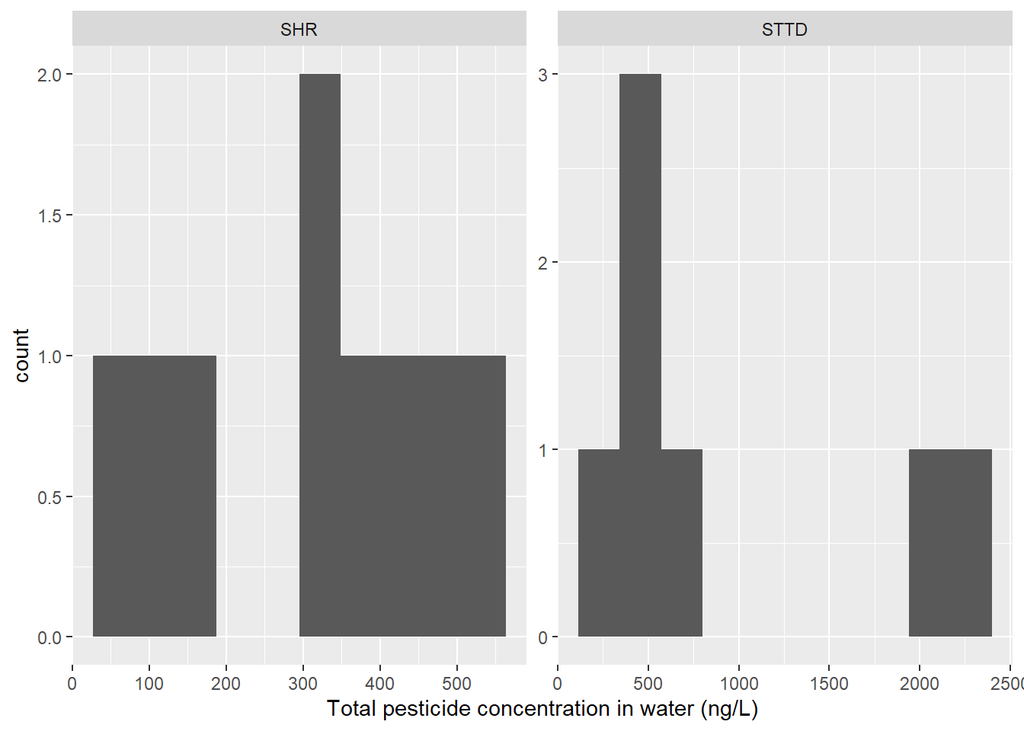

```r
df_water %>%
  ggplot(aes(x = TotalConc_Water)) +
  geom_histogram(bins = 10) +
  facet_wrap(vars(Station), scales = "free") +
  xlab("Total pesticide concentration in water (ng/L)")
```

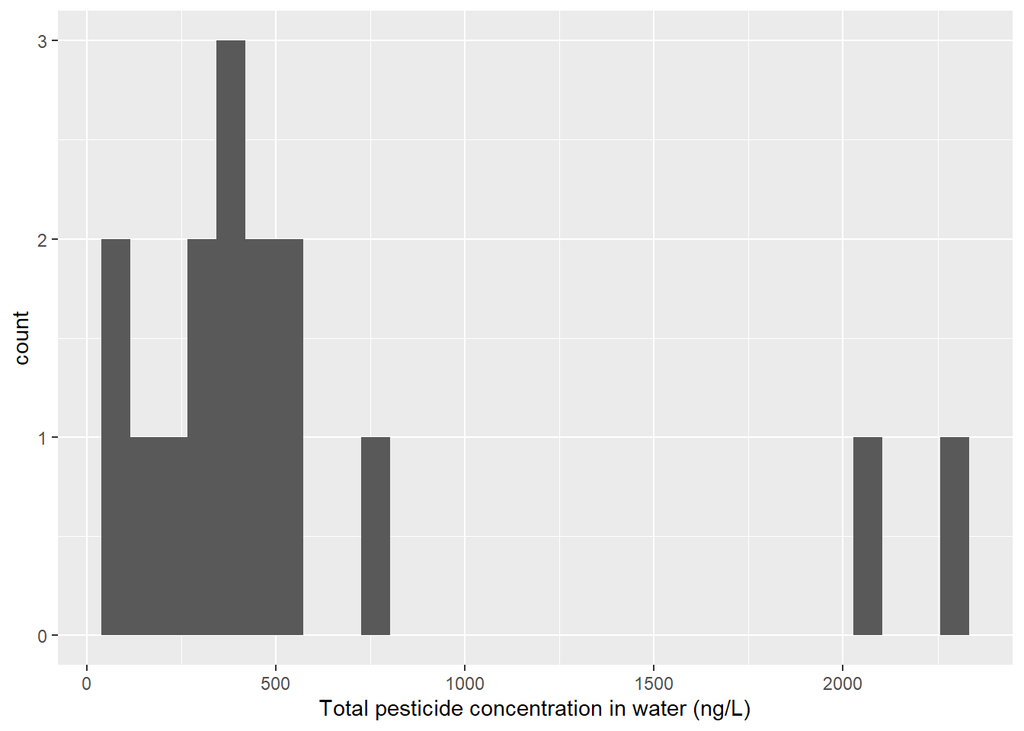

```r
df_water %>%
  ggplot(aes(x = TotalConc_Water)) +
  geom_histogram() +
  xlab("Total pesticide concentration in water (ng/L)")
```

We’ll probably need to use transformed water concentration data for the analyses.

## Analyses

### Models with Flow and Application

We’ll create linear models of the water concentrations as a function of daily average net flow and monthly pesticide application amounts for each station separately. We’ll start with the original concentration values, but we may need to transform them. These models will allow us to examine:

1. Do total pesticide concentrations in water significantly respond to flow at either or both SHR and STTD?
2. Do total pesticide concentrations in water significantly respond to pesticide application at either or both SHR and STTD?

#### SHR

We’ll start with SHR

```r
df_water_shr <- df_water %>% filter(Station == "SHR")

m_water_q_appl_shr <- df_water_shr %>%
  lm(TotalConc_Water ~ DailyAvgNetFlow + TotalApplStd, data = .)
```

Plot the diagnostics

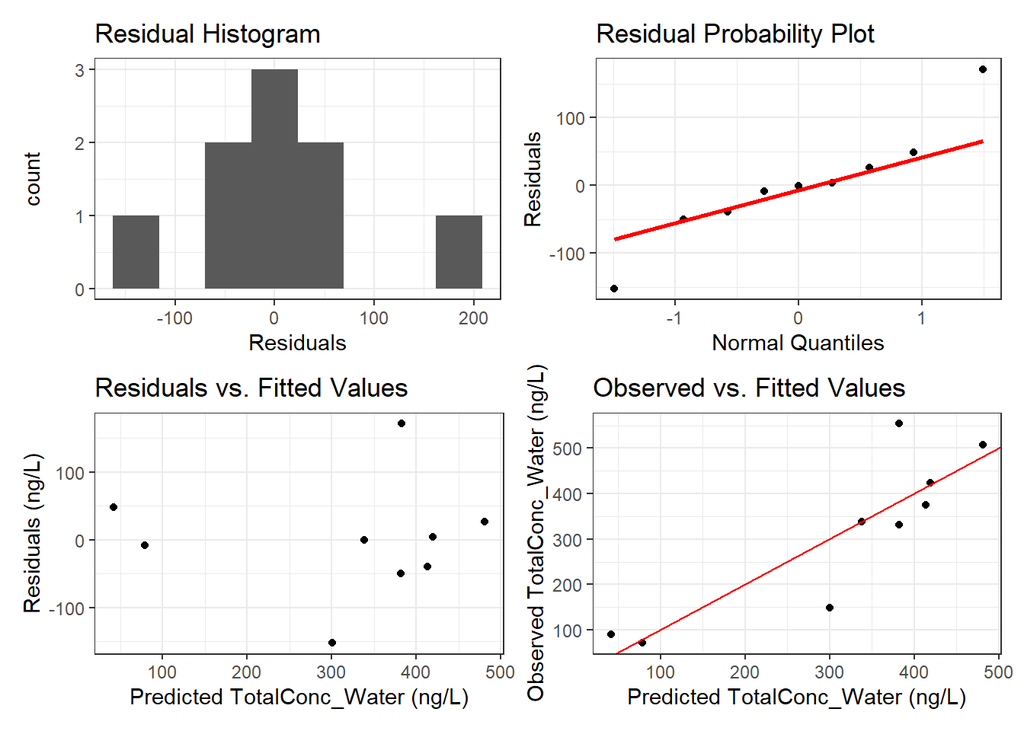

```r
df_water_shr %>% plot_model_diag(
  TotalConc_Water,
  "ng/L",
  m_water_q_appl_shr,
  bins = 8
)
```

```r
shapiro.test(m_water_q_appl_shr$residuals)
```

```
##
##  Shapiro-Wilk normality test
##
## data:  m_water_q_appl_shr$residuals
## W = 0.93721, p-value = 0.5529
```

The diagnostics look pretty good with this model, but let’s see if they look better with log transformed values.

```r
m_water_q_appl_shr_log <- df_water_shr %>%
  lm(TotalConc_Water_log ~ DailyAvgNetFlow + TotalApplStd, data = .)
```

Plot the diagnostics

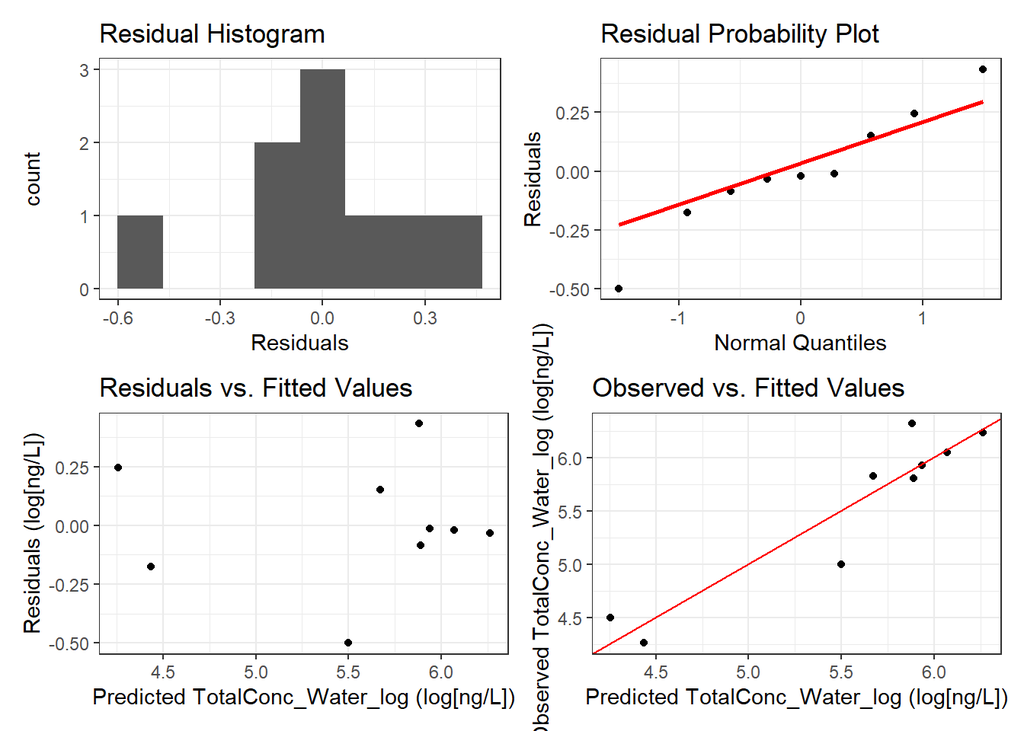

```r
df_water_shr %>% plot_model_diag(
  TotalConc_Water_log,
  "ng/L",
  m_water_q_appl_shr_log,
  trans = "log",
  bins = 8
)
```

```r
shapiro.test(m_water_q_appl_shr_log$residuals)
```

```
##
##  Shapiro-Wilk normality test
##
## data:  m_water_q_appl_shr_log$residuals
## W = 0.96314, p-value = 0.8305
```

The diagnostics look better with this model, so we’ll take a closer look at it.

```r
summary(m_water_q_appl_shr_log)
```

```
##
## Call:
## lm(formula = TotalConc_Water_log ~ DailyAvgNetFlow + TotalApplStd,
##     data = .)
##
## Residuals:
##      Min       1Q   Median       3Q      Max
## -0.50111 -0.08524 -0.02129  0.15153  0.43396
##
## Coefficients:
##                  Estimate Std. Error t value Pr(>|t|)
## (Intercept)     2.334e+00  5.277e-01   4.423  0.00446 **
## DailyAvgNetFlow 1.632e-04  2.827e-05   5.772  0.00118 **
## TotalApplStd    4.076e-02  1.416e-02   2.878  0.02815 *
## ---
## Signif. codes:  0 '***' 0.001 '**' 0.01 '*' 0.05 '.' 0.1 ' ' 1
##
## Residual standard error: 0.3062 on 6 degrees of freedom
## Multiple R-squared:  0.879,  Adjusted R-squared:  0.8387
## F-statistic:  21.8 on 2 and 6 DF,  p-value: 0.00177
```

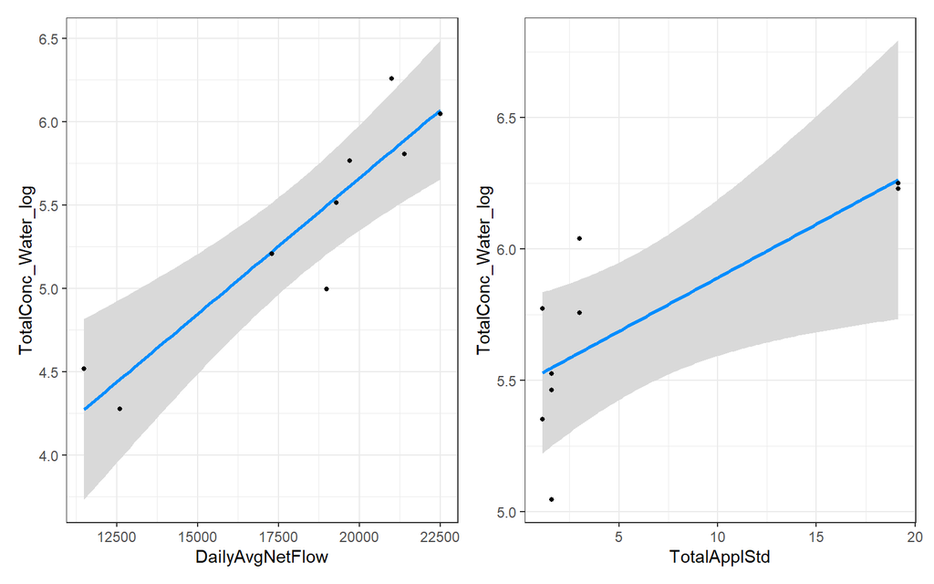

```r
plt_m_water_q_shr <- visreg(m_water_q_appl_shr_log, xvar = "DailyAvgNetFlow", gg = TRUE) +
  theme_bw() +
  geom_point(size = 1)

plt_m_water_appl_shr <- visreg(m_water_q_appl_shr_log, xvar = "TotalApplStd", gg = TRUE) +
  theme_bw() +
  geom_point(size = 1)

plt_m_water_shr <- plt_m_water_q_shr + plt_m_water_appl_shr
plt_m_water_shr
```

Total pesticide concentrations increase significantly with both flow and monthly pesticide application at the SHR station; however, the relationship with monthly pesticide application is driven by two values with the highest application.

##### Prior month application

Let’s see if the model is a better fit when we use the prior month’s application amount.

```r
m_water_q_appl_pr_shr <- df_water_shr %>%
  lm(TotalConc_Water ~ DailyAvgNetFlow + TotalApplStd_lag1, data = .)
```

Plot the diagnostics

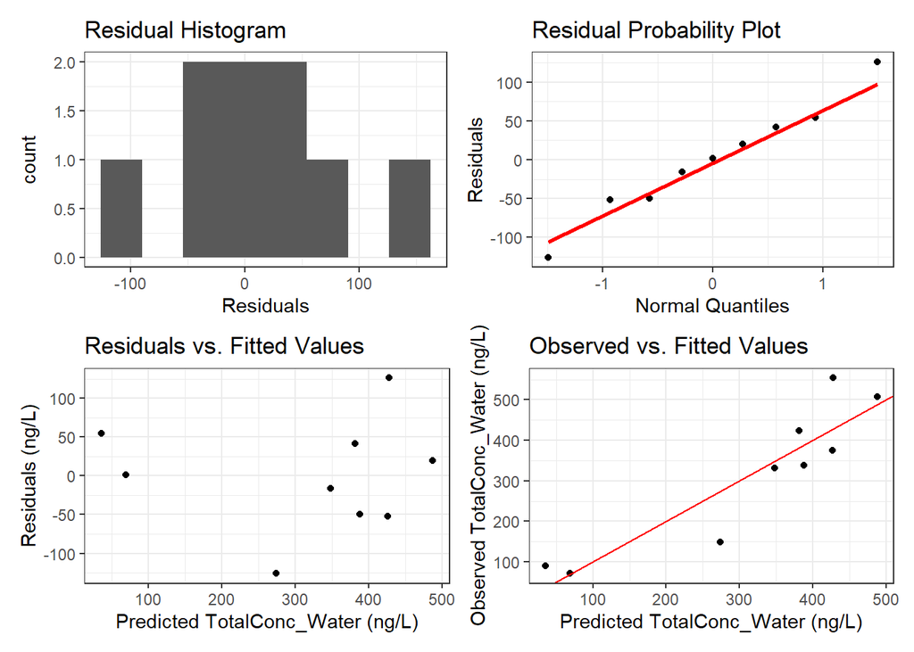

```r
df_water_shr %>% plot_model_diag(
  TotalConc_Water,
  "ng/L",
  m_water_q_appl_pr_shr,
  bins = 8
)
```

```r
shapiro.test(m_water_q_appl_pr_shr$residuals)
```

```
##
##  Shapiro-Wilk normality test
##
## data:  m_water_q_appl_pr_shr$residuals
## W = 0.98793, p-value = 0.9926
```

The model diagnostics look really good with the original values, so we’ll take a closer look at this model.

```r
summary(m_water_q_appl_pr_shr)
```

```
##
## Call:
## lm(formula = TotalConc_Water ~ DailyAvgNetFlow + TotalApplStd_lag1,
##     data = .)
##
## Residuals:
##      Min       1Q   Median       3Q      Max
## -126.095  -49.937    1.512   41.715  126.284
##
## Coefficients:
##                     Estimate Std. Error t value Pr(>|t|)
## (Intercept)       -3.270e+02  1.442e+02  -2.267  0.06395 .
## DailyAvgNetFlow    3.073e-02  7.887e-03   3.897  0.00802 **
## TotalApplStd_lag1  5.716e+00  1.937e+00   2.950  0.02561 *
## ---
## Signif. codes:  0 '***' 0.001 '**' 0.01 '*' 0.05 '.' 0.1 ' ' 1
##
## Residual standard error: 84.09 on 6 degrees of freedom
## Multiple R-squared:  0.8292, Adjusted R-squared:  0.7723
## F-statistic: 14.57 on 2 and 6 DF,  p-value: 0.004982
```

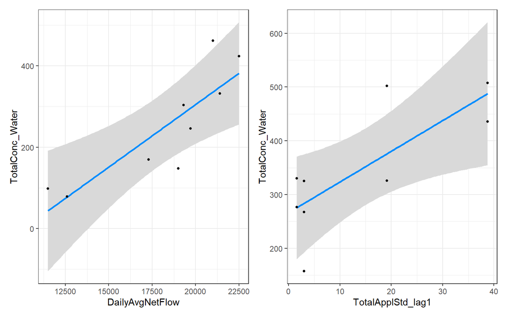

```r
plt_m_water_q_pr_shr <- visreg(m_water_q_appl_pr_shr, xvar = "DailyAvgNetFlow", gg = TRUE) +
  theme_bw() +
  geom_point(size = 1)

plt_m_water_appl_pr_shr <- visreg(m_water_q_appl_pr_shr, xvar = "TotalApplStd_lag1", gg = TRUE) +
  theme_bw() +
  geom_point(size = 1)

plt_m_water_pr_shr <- plt_m_water_q_pr_shr + plt_m_water_appl_pr_shr
plt_m_water_pr_shr
```

Again, total pesticide concentrations increase significantly with flow and monthly pesticide application at the SHR station using the prior month’s application. The relationship with monthly pesticide application isn’t as susceptible to leverage by values with the highest application.

##### Model selection

Let’s take a look at AIC and BIC values to see which model is better.

```r
AIC(m_water_q_appl_shr_log, m_water_q_appl_pr_shr)
```

```
##                        df        AIC
## m_water_q_appl_shr_log  4   8.586709
## m_water_q_appl_pr_shr   4 109.665709
```

```r
BIC(m_water_q_appl_shr_log, m_water_q_appl_pr_shr)
```

```
##                        df        BIC
## m_water_q_appl_shr_log  4   9.375607
## m_water_q_appl_pr_shr   4 110.454607
```

Both AIC and BIC strongly prefer the model with the current month’s pesticide application. However, both models aren’t using the same transformation for the response variable. I wonder if this changes if we use log-transformed values for the model with prior month’s application.

```r
m_water_q_appl_pr_shr_log <- df_water_shr %>%
  lm(TotalConc_Water_log ~ DailyAvgNetFlow + TotalApplStd_lag1, data = .)
```

Plot the diagnostics

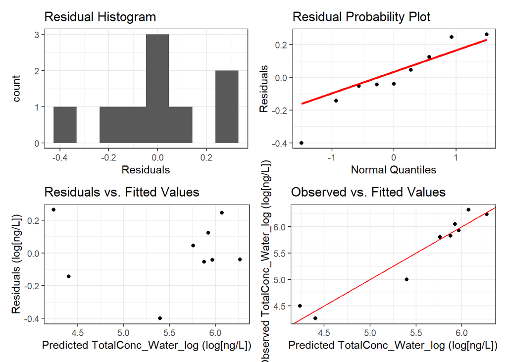

```r
df_water_shr %>% plot_model_diag(
  TotalConc_Water_log,
  "ng/L",
  m_water_q_appl_pr_shr_log,
  trans = "log",
  bins = 8
)
```

```r
shapiro.test(m_water_q_appl_pr_shr_log$residuals)
```

```
##
##  Shapiro-Wilk normality test
##
## data:  m_water_q_appl_pr_shr_log$residuals
## W = 0.93963, p-value = 0.5781
```

The model diagnostics aren’t as good with the log-transformed values. We’ll take a closer look at this model to see how it compares.

```r
summary(m_water_q_appl_pr_shr_log)
```

```
##
## Call:
## lm(formula = TotalConc_Water_log ~ DailyAvgNetFlow + TotalApplStd_lag1,
##     data = .)
##
## Residuals:
##      Min       1Q   Median       3Q      Max
## -0.40074 -0.05306 -0.03911  0.12387  0.26372
##
## Coefficients:
##                    Estimate Std. Error t value Pr(>|t|)
## (Intercept)       2.472e+00  4.053e-01   6.100 0.000885 ***
## DailyAvgNetFlow   1.504e-04  2.216e-05   6.786 0.000501 ***
## TotalApplStd_lag1 2.308e-02  5.443e-03   4.241 0.005435 **
## ---
## Signif. codes:  0 '***' 0.001 '**' 0.01 '*' 0.05 '.' 0.1 ' ' 1
##
## Residual standard error: 0.2362 on 6 degrees of freedom
## Multiple R-squared:  0.928,  Adjusted R-squared:  0.904
## F-statistic: 38.65 on 2 and 6 DF,  p-value: 0.0003736
```

```r
plt_m_water_q_pr_shr2 <- visreg(m_water_q_appl_pr_shr_log, xvar = "DailyAvgNetFlow", gg = TRUE) +
  theme_bw() +
  geom_point(size = 1)

plt_m_water_appl_pr_shr2 <- visreg(m_water_q_appl_pr_shr_log, xvar = "TotalApplStd_lag1", gg = TRUE) +
  theme_bw() +
  geom_point(size = 1)

plt_m_water_pr_shr2 <- plt_m_water_q_pr_shr2 + plt_m_water_appl_pr_shr2
```

The results are generally the same. Let’s take a look at AIC and BIC values using both models with log-transformed values.

```r
AIC(m_water_q_appl_shr_log, m_water_q_appl_pr_shr_log)
```

```
##                           df      AIC
## m_water_q_appl_shr_log     4 8.586709
## m_water_q_appl_pr_shr_log  4 3.920041
```

```r
BIC(m_water_q_appl_shr_log, m_water_q_appl_pr_shr_log)
```

```
##                           df      BIC
## m_water_q_appl_shr_log     4 9.375607
## m_water_q_appl_pr_shr_log  4 4.708940
```

Both AIC and BIC now prefer the model with the prior month’s pesticide application, but the difference isn’t as large. Since the diagnostics looked better for the model with the prior month’s pesticide application using the original values, let’s use the prior month model with original values for the model selection procedure. In this case, the best model is the one with the current month’s pesticide application.

#### STTD

Next, we’ll look at STTD

```r
df_water_sttd <- df_water %>% filter(Station == "STTD")

m_water_q_appl_sttd <- df_water_sttd %>%
  lm(TotalConc_Water ~ DailyAvgNetFlow + TotalApplStd, data = .)
```

Plot the diagnostics

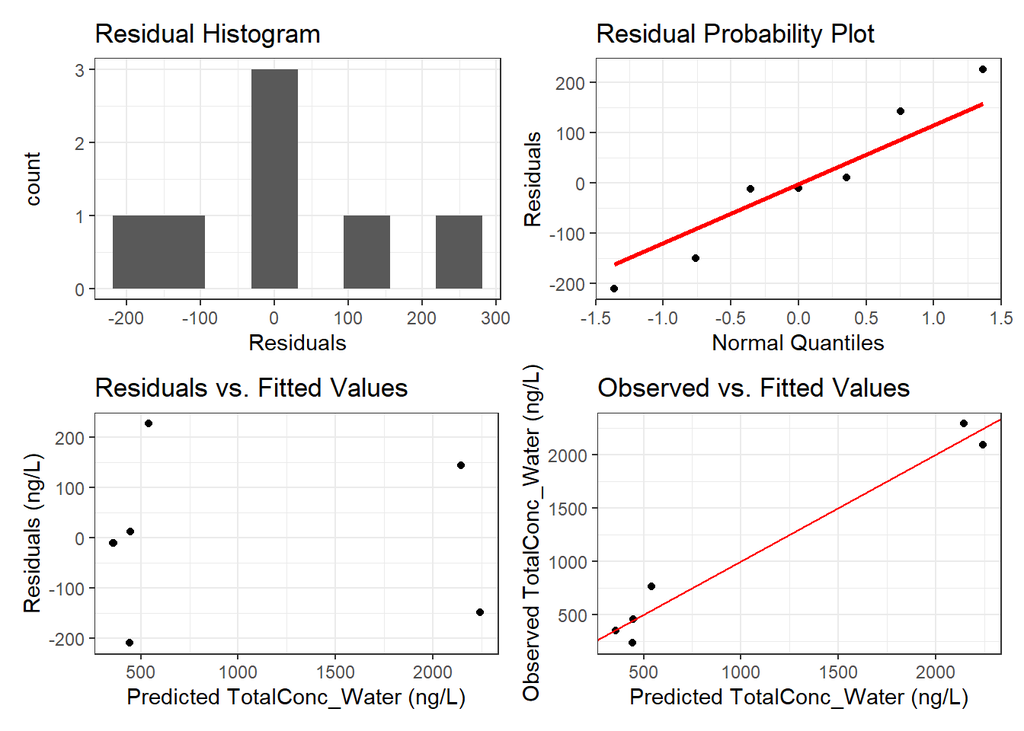

```r
df_water_sttd %>% plot_model_diag(
  TotalConc_Water,
  "ng/L",
  m_water_q_appl_sttd,
  bins = 8
)
```

```r
shapiro.test(m_water_q_appl_sttd$residuals)
```

```
##
##  Shapiro-Wilk normality test
##
## data:  m_water_q_appl_sttd$residuals
## W = 0.95545, p-value = 0.7789
```

The diagnostics look pretty good with the original values, so let’s take a closer look at this model.

```r
summary(m_water_q_appl_sttd)
```

```
##
## Call:
## lm(formula = TotalConc_Water ~ DailyAvgNetFlow + TotalApplStd,
##     data = .)
##
## Residuals:
##       1       2       3       4       5       6       7
##  -10.56   11.26  143.49 -149.01  226.58  -11.64 -210.12
##
## Coefficients:
##                 Estimate Std. Error t value Pr(>|t|)
## (Intercept)     613.1212   121.4666   5.048 0.007243 **
## DailyAvgNetFlow   2.6242     0.2426  10.816 0.000415 ***
## TotalApplStd     -4.9151     6.9025  -0.712 0.515747
## ---
## Signif. codes:  0 '***' 0.001 '**' 0.01 '*' 0.05 '.' 0.1 ' ' 1
##
## Residual standard error: 186.2 on 4 degrees of freedom
## Multiple R-squared:   0.97,  Adjusted R-squared:  0.9549
## F-statistic: 64.59 on 2 and 4 DF,  p-value: 0.000902
```

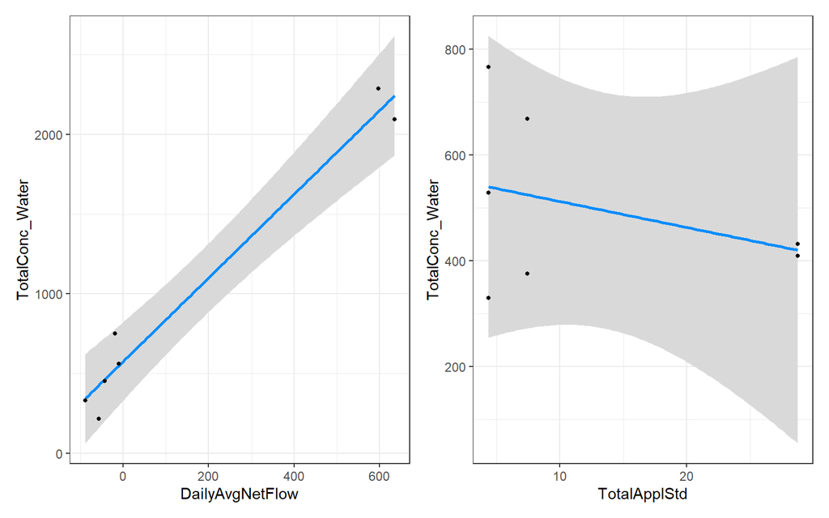

```r
plt_m_water_q_sttd <- visreg(m_water_q_appl_sttd, xvar = "DailyAvgNetFlow", gg = TRUE) +
  theme_bw() +
  geom_point(size = 1)

plt_m_water_appl_sttd <- visreg(m_water_q_appl_sttd, xvar = "TotalApplStd", gg = TRUE) +
  theme_bw() +
  geom_point(size = 1)

plt_m_water_sttd <- plt_m_water_q_sttd + plt_m_water_appl_sttd
plt_m_water_sttd
```

Total pesticide concentrations increase significantly with flow at the STTD station, but there are two values with flows of about 600 cfs that have a lot leverage on the model. The relationship between total pesticide concentration and monthly pesticide application wasn’t significant at STTD.

#### Prior month application

Let’s see if the model is a better fit when we use the prior month’s application amount.

```r
m_water_q_appl_pr_sttd <- df_water_sttd %>%
  lm(TotalConc_Water ~ DailyAvgNetFlow + TotalApplStd_lag1, data = .)
```

Plot the diagnostics

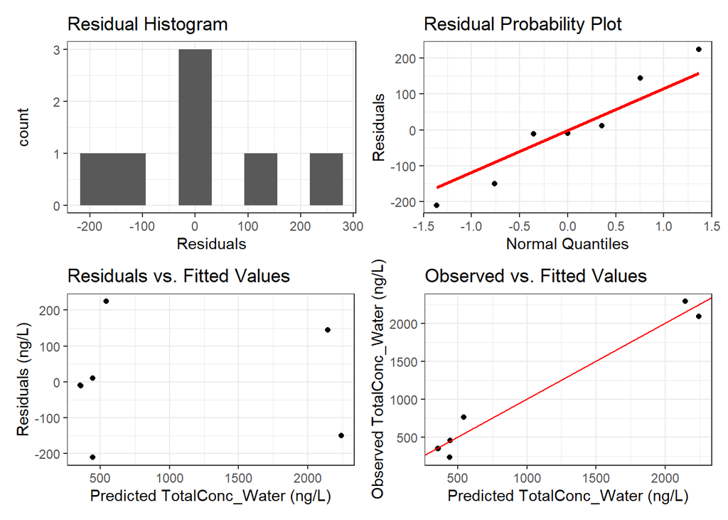

```r
df_water_sttd %>% plot_model_diag(
  TotalConc_Water,
  "ng/L",
  m_water_q_appl_pr_sttd,
  bins = 8
)
```

```r
shapiro.test(m_water_q_appl_pr_sttd$residuals)
```

```
##
##  Shapiro-Wilk normality test
##
## data:  m_water_q_appl_pr_sttd$residuals
## W = 0.95422, p-value = 0.7679
```

The model diagnostics look really good with the original values, so we’ll take a closer look at this model.

```r
summary(m_water_q_appl_pr_sttd)
```

```
##
## Call:
## lm(formula = TotalConc_Water ~ DailyAvgNetFlow + TotalApplStd_lag1,
##     data = .)
##
## Residuals:
##        1        2        3        4        5        6        7
##   -9.275   11.173  144.338 -149.681  224.672  -10.709 -210.517
##
## Coefficients:
##                   Estimate Std. Error t value Pr(>|t|)
## (Intercept)       609.5491   116.9936   5.210 0.006471 **
## DailyAvgNetFlow     2.6653     0.2349  11.348 0.000344 ***
## TotalApplStd_lag1  -2.0360     2.8321  -0.719 0.511962
## ---
## Signif. codes:  0 '***' 0.001 '**' 0.01 '*' 0.05 '.' 0.1 ' ' 1
##
## Residual standard error: 186 on 4 degrees of freedom
## Multiple R-squared:   0.97,  Adjusted R-squared:  0.955
## F-statistic: 64.74 on 2 and 4 DF,  p-value: 0.0008981
```

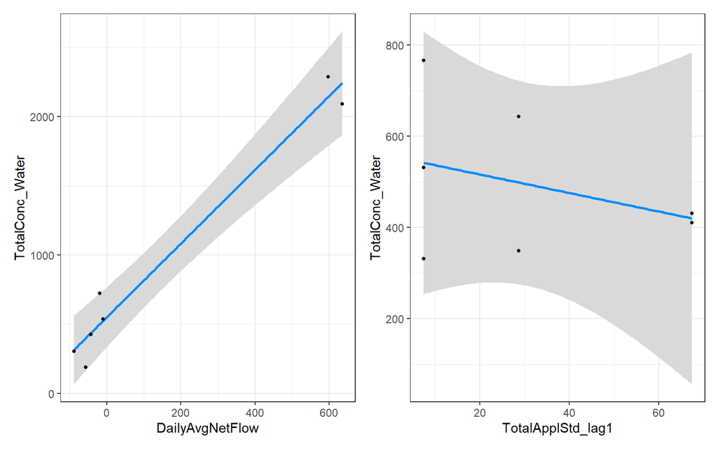

```r
plt_m_water_q_pr_sttd <- visreg(m_water_q_appl_pr_sttd, xvar = "DailyAvgNetFlow", gg = TRUE) +
  theme_bw() +
  geom_point(size = 1)

plt_m_water_appl_pr_sttd <- visreg(m_water_q_appl_pr_sttd, xvar = "TotalApplStd_lag1", gg = TRUE) +
  theme_bw() +
  geom_point(size = 1)

plt_m_water_pr_sttd <- plt_m_water_q_pr_sttd + plt_m_water_appl_pr_sttd
plt_m_water_pr_sttd
```

The results are the same with this model.

##### Model selection

Let’s take a look at AIC and BIC values to see which model is better.

```r
AIC(m_water_q_appl_sttd, m_water_q_appl_pr_sttd)
```

```
##                        df      AIC
## m_water_q_appl_sttd     4 97.12213
## m_water_q_appl_pr_sttd  4 97.10699
```

```r
BIC(m_water_q_appl_sttd, m_water_q_appl_pr_sttd)
```

```
##                        df      BIC
## m_water_q_appl_sttd     4 96.90577
## m_water_q_appl_pr_sttd  4 96.89063
```

The AIC and BIC values are nearly identical between models with both metrics giving a slight edge to the model with the prior month’s pesticide application. However, monthly pesticide application isn’t significant in either model.

### Station comparison

Next, let’s compare total pesticide concentrations in water between the two stations, SHR and STTD. Since samples were only collected at both stations in 2019, we can run a simple t-test to compare them. The histogram of all water concentrations above showed that they are not normally-distributed. Let’s take a look at the natural log transformed values to see if we can use these for the t-test.

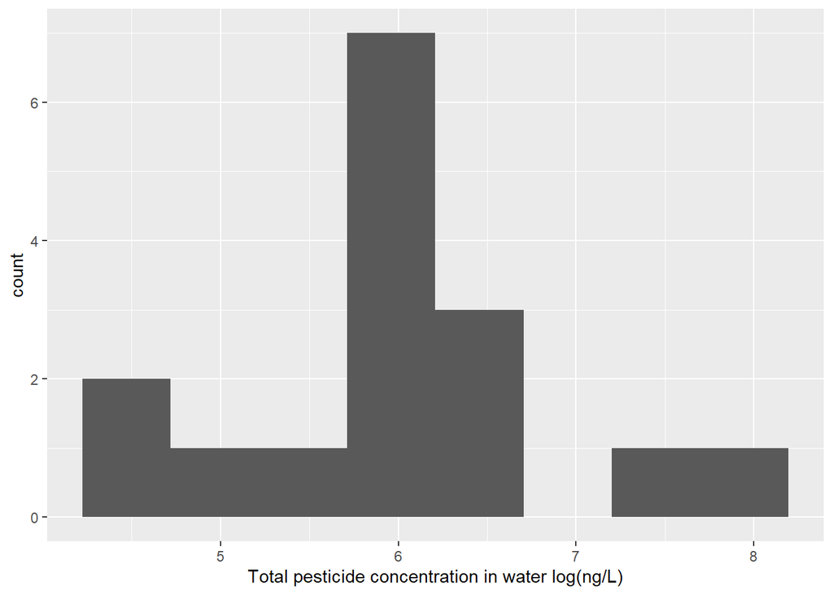

```r
df_water %>%
  ggplot(aes(x = TotalConc_Water_log)) +
  geom_histogram(bins = 8) +
  xlab("Total pesticide concentration in water log(ng/L)")
```

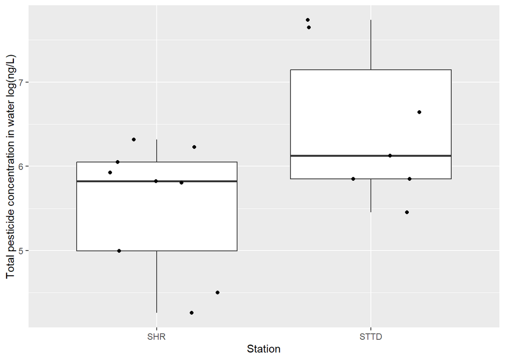

```r
df_water %>%
  ggplot(aes(x = Station, y = TotalConc_Water_log)) +
  geom_boxplot(outlier.shape = NA) +
  geom_jitter(width = 0.3) +
  ylab("Total pesticide concentration in water log(ng/L)")
```

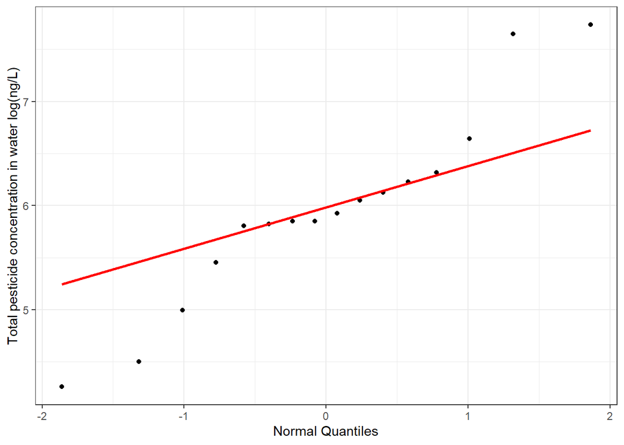

```r
df_water %>%
  ggplot(aes(sample = TotalConc_Water_log)) +
  labs(
    x = "Normal Quantiles",
    y = "Total pesticide concentration in water log(ng/L)"
  ) +
  stat_qq() +
  stat_qq_line(linewidth = 1, color = 'red') +
  theme_bw()
```

```r
shapiro.test(df_water$TotalConc_Water_log)
```

```
##
##  Shapiro-Wilk normality test
##
## data:  df_water$TotalConc_Water_log
## W = 0.93391, p-value = 0.2809
```

The natural log transformed values seem to be more normally distributed and have relatively equal variances between SHR and STTD. Let’s run Welch’s two-sample t-test to compare the means of total pesticide concentration in water between SHR and STTD.

```r
df_water %>% t.test(TotalConc_Water_log ~ Station, data = .)
```

```
##
##  Welch Two Sample t-test
##
## data:  TotalConc_Water_log by Station
## t = -2.1709, df = 11.742, p-value = 0.05119
## alternative hypothesis: true difference in means between group SHR and group STTD is not equal to 0
## 95 percent confidence interval:
##  -1.858996839  0.005652187
## sample estimates:
##  mean in group SHR mean in group STTD
##           5.545113           6.471786
```

# Overall Conclusions

## Zooplankton

Total pesticide concentrations in Zooplankton:

- Total pesticide concentrations decreased significantly with flow (p = 0.00013) and monthly pesticide application (p = 0.00020) at the SHR station; however, the relationship with monthly pesticide application was driven by four values with the highest application.

```
##
## Call:
## lm(formula = TotalConc_Zoop_log ~ DailyAvgNetFlow + TotalApplStd,
##     data = .)
##
## Residuals:
##      Min       1Q   Median       3Q      Max
## -0.59245 -0.12635 -0.02903  0.17388  0.49120
##
## Coefficients:
##                   Estimate Std. Error t value Pr(>|t|)
## (Intercept)      7.364e+00  3.196e-01  23.041 8.26e-15 ***
## DailyAvgNetFlow -8.287e-05  1.712e-05  -4.841 0.000131 ***
## TotalApplStd    -4.318e-02  9.271e-03  -4.657 0.000196 ***
## ---
## Signif. codes:  0 '***' 0.001 '**' 0.01 '*' 0.05 '.' 0.1 ' ' 1
##
## Residual standard error: 0.2726 on 18 degrees of freedom
## Multiple R-squared:  0.7004, Adjusted R-squared:  0.6671
## F-statistic: 21.04 on 2 and 18 DF,  p-value: 1.944e-05
```

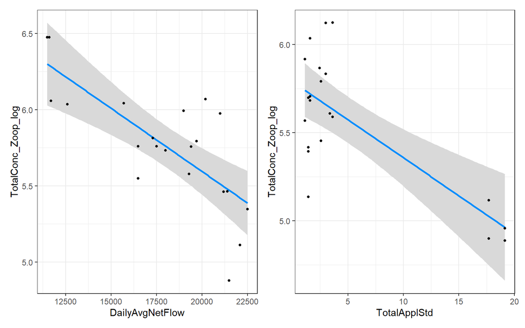

- Total pesticide concentrations increased significantly with flow at the STTD station (p = 0.00047), but there was no relationship between concentration and monthly pesticide application (p = 0.78).

```
##
## Call:
## lm(formula = TotalConc_Zoop_sqrt ~ DailyAvgNetFlow + TotalApplStd,
##     data = .)
##
## Residuals:
##      Min       1Q   Median       3Q      Max
## -11.1552  -3.4770  -0.8651   4.8538  12.0845
##
## Coefficients:
##                  Estimate Std. Error t value Pr(>|t|)
## (Intercept)     13.760969   1.920517   7.165 1.58e-06 ***
## DailyAvgNetFlow  0.025096   0.005822   4.311 0.000474 ***
## TotalApplStd    -0.021261   0.074230  -0.286 0.778020
## ---
## Signif. codes:  0 '***' 0.001 '**' 0.01 '*' 0.05 '.' 0.1 ' ' 1
##
## Residual standard error: 5.754 on 17 degrees of freedom
## Multiple R-squared:  0.5549, Adjusted R-squared:  0.5025
## F-statistic:  10.6 on 2 and 17 DF,  p-value: 0.001028
```

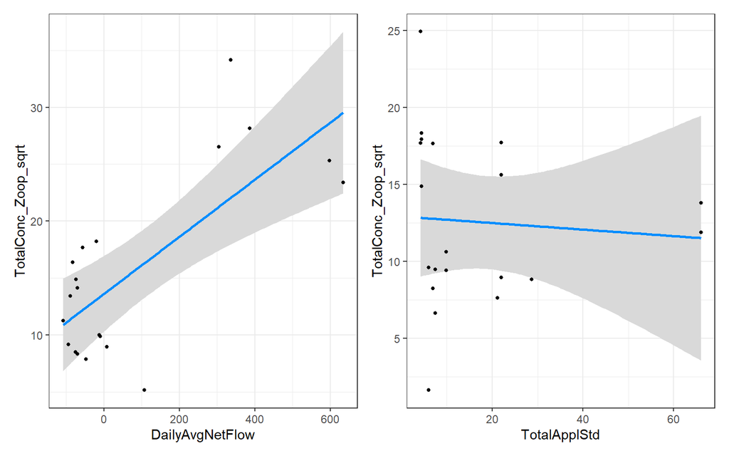

```
## Anova Table (Type II tests)
##
## Response: TotalConc_Zoop_log
##            Sum Sq Df F value  Pr(>F)
## Station    1.8028  1  3.1690 0.08326 .
## Year       3.8276  2  3.3641 0.04546 *
## Residuals 21.0492 37
## ---
## Signif. codes:  0 '***' 0.001 '**' 0.01 '*' 0.05 '.' 0.1 ' ' 1
```

```
##  contrast   estimate    SE df t.ratio p.value
##  SHR - STTD    0.424 0.238 37   1.780  0.0833
##
## Results are averaged over the levels of: Year
```

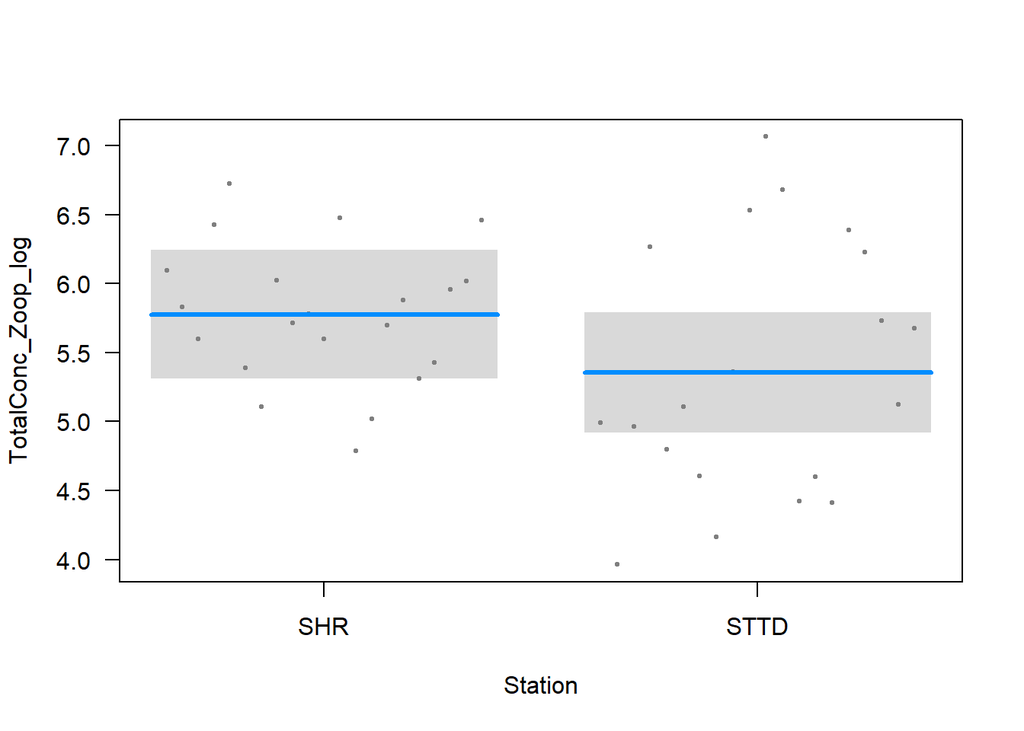

- Zooplankton concentrations were marginally significantly higher (p = 0.053) in 2019 than 2017 across both stations.

```
##  contrast            estimate    SE df t.ratio p.value
##  Year2017 - Year2018  -0.6700 0.304 37  -2.201  0.0842
##  Year2017 - Year2019  -0.7474 0.309 37  -2.420  0.0525
##  Year2018 - Year2019  -0.0774 0.274 37  -0.283  0.9570
##
## Results are averaged over the levels of: Station
## P value adjustment: tukey method for comparing a family of 3 estimates
```

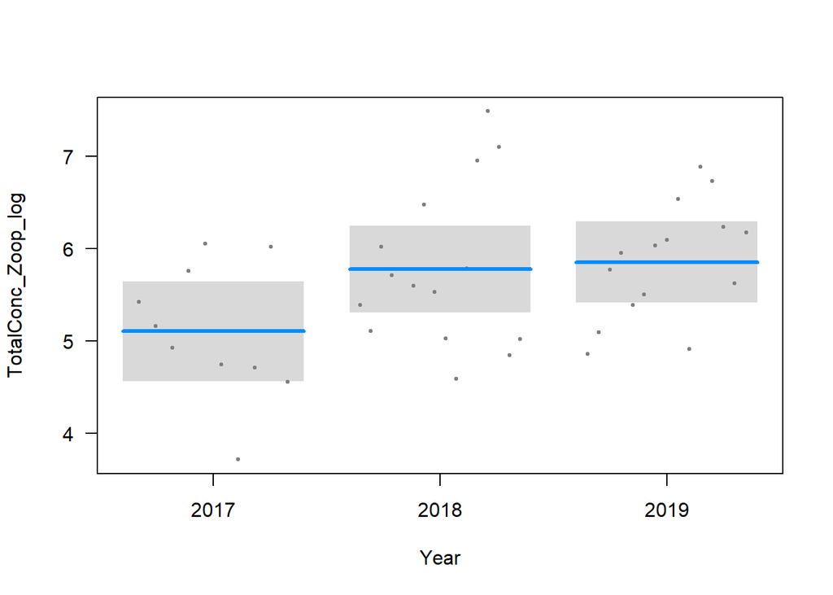

## Water

Total pesticide concentrations in Water:

- Total pesticide concentrations increased significantly with both flow (p = 0.0012) and monthly pesticide application (p = 0.028) at the SHR station; however, the relationship with monthly pesticide application is driven by two values with the highest application.

```
##
## Call:
## lm(formula = TotalConc_Water_log ~ DailyAvgNetFlow + TotalApplStd,
##     data = .)
##
## Residuals:
##      Min       1Q   Median       3Q      Max
## -0.50111 -0.08524 -0.02129  0.15153  0.43396
##
## Coefficients:
##                  Estimate Std. Error t value Pr(>|t|)
## (Intercept)     2.334e+00  5.277e-01   4.423  0.00446 **
## DailyAvgNetFlow 1.632e-04  2.827e-05   5.772  0.00118 **
## TotalApplStd    4.076e-02  1.416e-02   2.878  0.02815 *
## ---
## Signif. codes:  0 '***' 0.001 '**' 0.01 '*' 0.05 '.' 0.1 ' ' 1
##
## Residual standard error: 0.3062 on 6 degrees of freedom
## Multiple R-squared:  0.879,  Adjusted R-squared:  0.8387
## F-statistic:  21.8 on 2 and 6 DF,  p-value: 0.00177
```

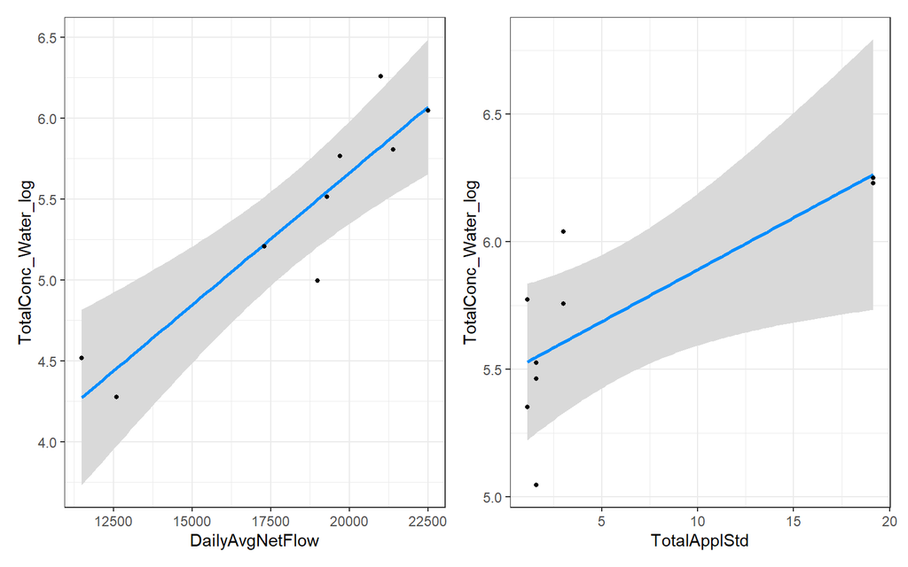

- Total pesticide concentrations also increased significantly with flow (p = 0.00042) at the STTD station, but there were two values with flows of about 600 cfs that had a lot leverage on the model. The relationship between total pesticide concentration and monthly pesticide application wasn’t significant at STTD (p = 0.52).

```
##
## Call:
## lm(formula = TotalConc_Water ~ DailyAvgNetFlow + TotalApplStd,
##     data = .)
##
## Residuals:
##       1       2       3       4       5       6       7
##  -10.56   11.26  143.49 -149.01  226.58  -11.64 -210.12
##
## Coefficients:
##                 Estimate Std. Error t value Pr(>|t|)
## (Intercept)     613.1212   121.4666   5.048 0.007243 **
## DailyAvgNetFlow   2.6242     0.2426  10.816 0.000415 ***
## TotalApplStd     -4.9151     6.9025  -0.712 0.515747
## ---
## Signif. codes:  0 '***' 0.001 '**' 0.01 '*' 0.05 '.' 0.1 ' ' 1
##
## Residual standard error: 186.2 on 4 degrees of freedom
## Multiple R-squared:   0.97,  Adjusted R-squared:  0.9549
## F-statistic: 64.59 on 2 and 4 DF,  p-value: 0.000902
```

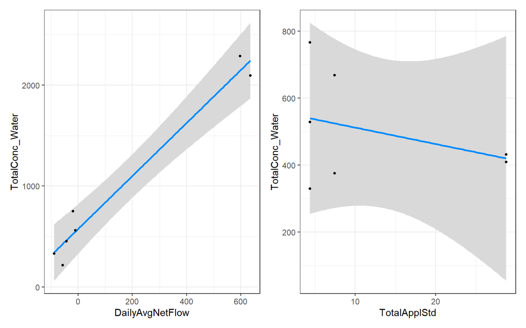

```
##
##  Welch Two Sample t-test
##
## data:  TotalConc_Water_log by Station
## t = -2.1709, df = 11.742, p-value = 0.05119
## alternative hypothesis: true difference in means between group SHR and group STTD is not equal to 0
## 95 percent confidence interval:
##  -1.858996839  0.005652187
## sample estimates:
##  mean in group SHR mean in group STTD
##           5.545113           6.471786
```